# Negativas de acesso a informação no governo Federal

Órgãos e entidades do poder Executivo - janeiro de 2015 até 2021

```r
library(tidyverse)
library(lubridate)
library(glue)
library(here)
library(ggtext)
library(patchwork)
library(kableExtra)
library(hrbrthemes)

set.seed(1014)

knitr::knit_hooks$set(inline = function(x) prettyNum(x, big.mark = ".", decimal.mark = ","))

options(digits = 1,
        scipen = 999,
        OutDec = ",",
        knitr.kable.NA = '')

Sys.setenv(LANGUAGE = "pt-br")
Sys.setlocale("LC_TIME", "pt_BR")
```

```
#> [1] ""
```

```r
# aplica identidade visual da TB/AeP
aep_colors <- c(

  laranja = "#F9A521",
  rosa = "#D81755",
  cinza = "#969696",
  marrom = "#B27D5C"

)

paleta_governo = c(

  `Dilma II` = aep_colors[["laranja"]],
  `Temer` = aep_colors[["cinza"]],
  `Bolsonaro` = aep_colors[["rosa"]]

)

tb_colors <- c(

  laranja = "#F6A323",
  cinza_escuro = "#1d1d1b",
  cinza_claro =  "#6f7171",
  cinza_quase_branco = "#ececec",
  azul = "#41ACBD"

  )

cores_decisao <- c(

  "Acesso Concedido" = tb_colors[["azul"]],
  "Não se trata de solicitação de informação" = aep_colors[["marrom"]],
  "Acesso Negado" = aep_colors[["rosa"]],
  "Acesso Parcialmente Concedido" = aep_colors[["laranja"]],
  "Pergunta Duplicada/Repetida" = aep_colors[["cinza"]],
  "Órgão não tem competência para responder sobre o assunto" = tb_colors[["cinza_escuro"]],
  "Informação Inexistente" = tb_colors[["cinza_quase_branco"]]

  )
```

```r
periodo_final <- "2021-07-01"
instancias_recursais <- c("Primeira Instância",
                          "Segunda Instância",
                          "Terceira Instância",
                          "CGU",
                          "CMRI",
                          "Pedido de Revisão",
                          "Não houve recurso")

pedidos_cgu <- readRDS(here("dados/load/rds/pedidos-clean.rds")) %>%
  filter(data_resposta <= periodo_final, data_resposta <= periodo_final)

recursos_cgu <- readRDS(here("dados/load/rds/recursos-clean.rds")) %>%
  filter(data_resposta <= periodo_final, data_resposta <= periodo_final) %>%
  mutate(instancia = ordered(instancia, levels = instancias_recursais))
```

> **Tipo recurso**: motivo da abertura do recurso
- Informação incompleta
- Outros
- Justificativa para o sigilo insatisfatória/não informada
- Informação recebida não corresponde à solicitada
- Ausência de justificativa legal para classificação
- Grau de classificação inexistente
- Informação recebida por meio diferente do solicitado
- Resposta não foi dada no prazo
- Informação classificada por autoridade sem competência
- Autoridade classificadora não informada
- Grau de sigilo não informado
- Data da classificação (de início ou fim) não informada
- Prazo de classificação inadequado para o grau de sigilo
- Não concorda com a transformação do pedido em manifestação de ouvidoria
- Deferimento de pedido de revisão para transformar pedido em manifestação

> **Instância**: descrição da instância do recurso
- Primeira Instância
- Segunda Instância
- Terceira Instância
- CGU
- CMRI
- Pedido de Revisão
- Não houve recurso

> **Decisão**: tipo de resposta dada ao pedido
- Acesso Concedido
- Pergunta Duplicada/Repetida
- Acesso Parcialmente Concedido
- Acesso Negado
- Não se trata de solicitação de informação
- Órgão não tem competência para responder sobre o assunto
- Informação InexistenteAcesso concedido

> **Índice de acesso a informação**: proporção de solicitações atendidas em relação às decisões de Acesso Negado, Acesso Concedido, Acesso Parcialmente Concedido, Órgão não tem competencia para responder sobre assunto, Informação Ineistente, Não se trata de solicitação de informação, Pergunta Duplicada

### To do

> **Termos controversos**: termos que indicam negativas ou descumprimento da LAI (previsão: sprint **26/08**)
- Pedido desarrazoado ou desproporcional (`desarrazoado|desproporciona`)
- Fishing expedition (`fishing`)
- Segurança Nacional (`segurança [nacional|do estado]`)
- Sigilo (`sigilo`)
- Decisão em curso (`processo decisorio em curso|documento preparatorio`)
- Trabalho adicional (`trabalho[s]? adiciona`)
- Pedido Genérico (`generico`)
- LGPD (`lei geral de proteção de dados|lei de protecao de dados pessoais|13\\.?709|13\\.?853|lgpd`)

> **Análise de série temporal**: Reprocessar forecasting e iniciar análise de série temporal (sazonalidade, estacionariedade, modelos autorregressivos básicos) (previsão: sprint **09/09**)

> **Análise por órgãos**: Listar órgãos que mais negam informações (previsão: sprint **23/09**)

> **Análise por tempo de resposta**: Qual período mais descumpriu prazos da LAI? Quais órgãos? (previsão: sprint **07/10**)

## Pedidos de acesso a informação

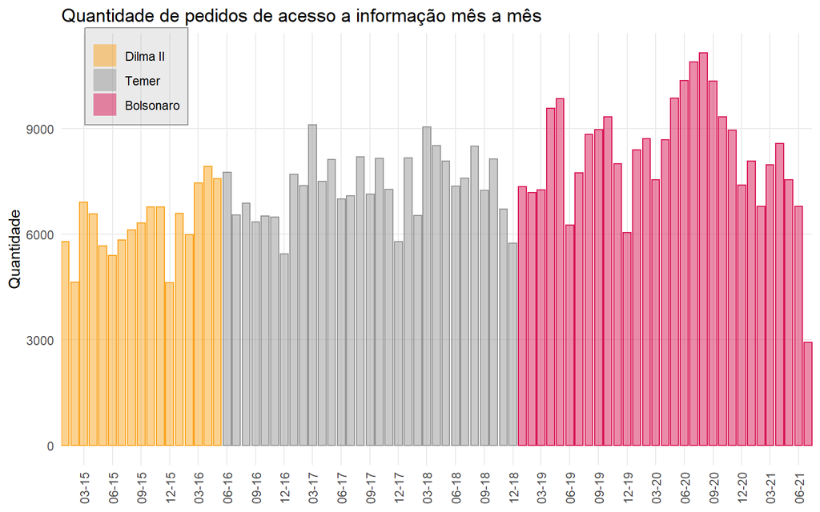

```r
pedidos_por_mes <- pedidos_cgu %>%
  group_by(data_registro, governo_que_registrou) %>%
  summarise(qt = n(), .groups = "drop")

pedidos_por_mes %>%
  ggplot() +
  geom_bar(
    aes(x = data_registro, y = qt, fill = governo_que_registrou, color = governo_que_registrou),
    stat = "identity",
    alpha = .5
  ) +
  theme_minimal() +
  scale_fill_manual(values = paleta_governo) +
  scale_color_manual(values = paleta_governo) +
  scale_x_date(breaks = scales::date_breaks("3 months"), date_labels = "%m-%y", expand = c(0, 0)) +
  labs(
    y = "Quantidade",
    x = NULL,
    fill = NULL,
    title = "Quantidade de pedidos de acesso a informação mês a mês"
  ) +
  theme(
    axis.text.x = element_text(hjust = .5, vjust = .5, angle = 90),
    legend.position = c(.1, .9),
    panel.grid.minor = element_blank(),
    legend.background = element_rect(
      fill = alpha(aep_colors[["cinza"]], .2),
      color = aep_colors[["cinza"]]
    )
  ) +
  guides(color = "none")
```

## Atendimento da Lei de Acesso a Informação

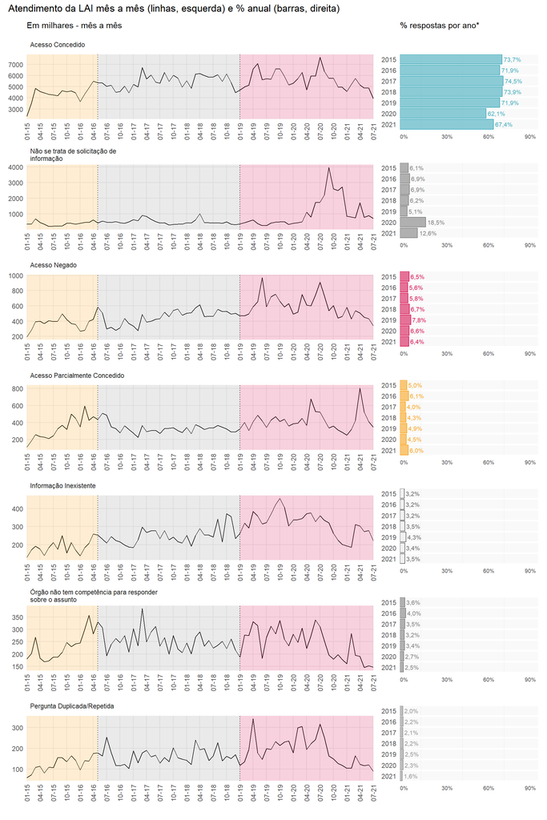

```r
# cores de fundo ---------------------------------------------------------------
rect_gov <- tibble(
  governo_que_respondeu = c("Dilma II", "Temer", "Bolsonaro"),
  xmin = c("2015-01-01", "2016-05-01", "2019-01-01"), # inicio de cada governo
  xmax = lead(xmin, default = periodo_final),         # fim de cada governo
  ymin = -Inf,
  ymax = Inf
) %>% mutate(across(xmin:xmax, ~ as_date(ymd(.x))))

# tipo respostas mais comuns histórico -----------------------------------------
decisao <- pedidos_cgu %>%
  group_by(data_resposta, decisao, governo_que_respondeu) %>%
  summarise(qt = n(), .groups = "drop") %>%
  mutate(decisao = fct_reorder(str_wrap(decisao, 40), qt, .desc = T))

# plot esquerdo ----------------------------------------------------------------
p1 <- decisao %>%
  ggplot() +
  geom_line(aes(x = data_resposta, y = qt), show.legend = F) +
  geom_vline(xintercept = ymd(c("2016-05-01", "2019-01-01")), lty = 3) +
  geom_rect(
    data = rect_gov,
    aes(xmin = xmin, xmax = xmax, ymin = ymin, ymax = ymax, fill = governo_que_respondeu),
    alpha = .2, show.legend = F
  ) +
  scale_fill_manual(values = paleta_governo) +
  scale_color_manual(values = paleta_governo) +
  theme_minimal() +
  theme(
    legend.position = "top",
    legend.text = element_text(size = 8),
    axis.text.x = element_text(hjust = .5, vjust = .5, angle = 90),
    panel.grid.minor = element_blank(),
    strip.text = element_text(angle = 0, hjust = 0)
  ) +
  scale_x_date(breaks = scales::date_breaks("3 months"), date_labels = "%m-%y", expand = c(0, 0)) +
  labs(
    x = NULL,
    y = NULL,
    subtitle = "Em milhares - mês a mês",
    color = NULL,
    fill = NULL
  ) +
  facet_wrap(~ reorder(decisao, -qt), scales = 'free', ncol = 1)

# plot direito -----------------------------------------------------------------
cores_decisao2 <- cores_decisao
cores_decisao2[["Informação Inexistente"]] <- "gray40"

p2 <- decisao %>%
  group_by(ano = year(data_resposta), decisao) %>%
  summarise(qt = sum(qt), .groups = "drop") %>%
  group_by(ano) %>%
  mutate(qt_ano = sum(qt),
         perc_ano = qt / qt_ano) %>%
  ungroup() %>%
  arrange(decisao, ano) %>%
  ggplot(aes(x = perc_ano, y = reorder(ano, -ano), fill = decisao, color = decisao)) +
  facet_wrap(~ reorder(decisao, -perc_ano), ncol = 1, scales = "free_x") +
  geom_col(aes(x = 1), alpha = .3, fill = tb_colors[["cinza_quase_branco"]], color = "white") +
  geom_col(alpha = .6) +
  geom_text(aes(label = scales::percent(perc_ano, accuracy = 0.1, decimal.mark = ",")),
             size = 2.8, hjust = -.1, check_overlap = T) +
  theme_minimal() +
  scale_fill_manual(values = cores_decisao) +
  scale_color_manual(values = cores_decisao2) +
  scale_y_discrete(expand = c(0, 0)) +
  scale_x_continuous(expand = c(0, 0), labels = scales::percent_format(), limits = c(0,1),
                     breaks = c(0,.3, .6, .9)) +
  theme(
    plot.subtitle = element_text(),
    panel.grid.major.y = element_line(color = "white"),
    panel.grid.major.x = element_blank(),
    panel.grid.minor.y = element_line(color = "white"),
    panel.background = element_blank(),#rect(fill = tb_colors[["cinza_quase_branco"]], color = "transparent"),
    strip.text = element_text(hjust = 0, vjust = 0, color = "white"),
    axis.text.x = element_text(hjust = 0, vjust = 0, size = 7)
  ) +
  labs(
    x = "",
    y = NULL,
    fill = NULL,
    subtitle = "% respostas por ano*"
  )

comb <- p1 + p2 & theme(legend.position = "none")
comb +
  plot_layout(widths = c(2.5, 1)) +
  plot_annotation(title = "Atendimento da LAI mês a mês (linhas, esquerda) e % anual (barras, direita)")
```

```r
pedidos_por_ano_e_decisao <- function(df, catg_decisao) {

  if (catg_decisao != "Total") df <- filter(df, decisao == catg_decisao)

  df %>%
    select(data_resposta, id_pedido) %>%
    mutate(data_resposta = floor_date(data_resposta, unit = "year")) %>%
    group_by(data_resposta) %>%
    summarise(qt = n() / 1e3, .groups = "drop") %>%
    mutate(ano = ordered(year(data_resposta)), categoria = catg_decisao)

}
```

### Índice de acessos concedidos

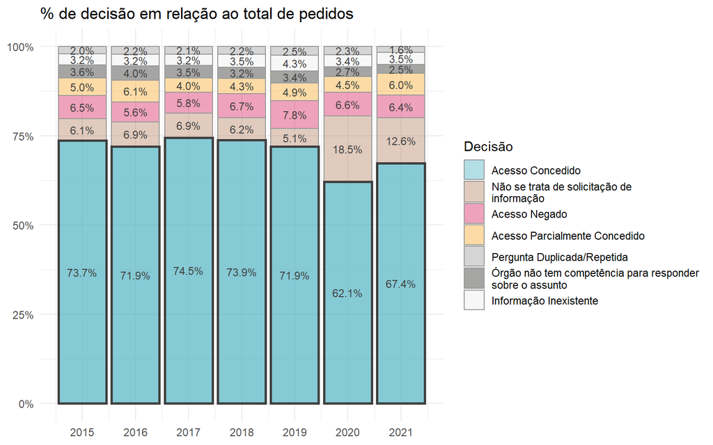

```r
names(cores_decisao) <- str_wrap(names(cores_decisao), 40)

pedidos_cgu %>%
  group_by(data_resposta = year(data_resposta), decisao) %>%
  summarise(qt = n() / 1e3, .groups = "drop") %>%
  mutate(decisao = fct_reorder(str_wrap(decisao, 40), qt)) %>%
  group_by(data_resposta) %>%
  mutate(qt_ano = sum(qt)) %>%
  ungroup() %>%
  ggplot(aes(x = data_resposta, y = qt / qt_ano, fill = decisao)) +
  geom_col(position = "fill", alpha = .4, color = "gray60") +
  geom_col(data = . %>%  filter(decisao == "Acesso Concedido"),
           alpha = .4,
           color = "gray25",
           size = 1,
           show.legend = F) +
  geom_text(aes(label = scales::percent(qt / qt_ano, accuracy = 0.1)),
            position = position_stack(vjust = .5),
            color = 'gray25',
            size = 3) +
  scale_y_continuous(labels = scales::percent) +
  scale_x_continuous(breaks = 2015:2021, labels = 2015:2021) +
  labs(x = NULL, y = NULL, fill = "Decisão",
       title = "% de decisão em relação ao total de pedidos") +
  theme_minimal() +
  scale_fill_manual(values = cores_decisao) +
  scale_color_manual(values = cores_decisao)
```

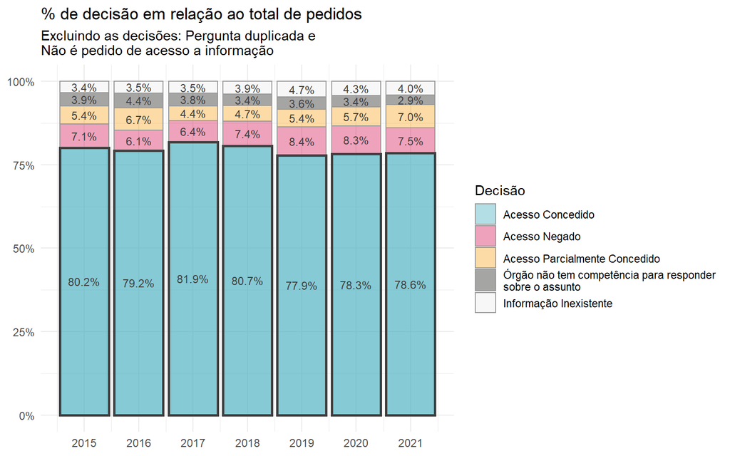

```r
`%notin%` <- function(x, y) !(x %in% y)

pedidos_cgu %>%
  filter(decisao %notin% c(
    "Pergunta Duplicada/Repetida",
    "Não se trata de solicitação de informação"
  )) %>%
  mutate(data_resposta = floor_date(data_resposta, unit = "year")) %>%
  group_by(data_resposta = year(data_resposta), decisao) %>%
  summarise(qt = n() / 1e3, .groups = "drop") %>%
  mutate(decisao = fct_reorder(str_wrap(decisao, 40), qt)) %>%
  group_by(data_resposta) %>%
  mutate(qt_ano = sum(qt)) %>%
  ungroup() %>%
  ggplot(aes(x = data_resposta, y = qt / qt_ano, fill = decisao)) +
  geom_col(position = "fill", color = "gray60", alpha = .4) +
  geom_col(data = . %>%  filter(decisao == "Acesso Concedido"),
           color = "gray25",
           alpha = .4,
           size = 1,
           show.legend = F) +
  geom_text(aes(label = scales::percent(qt / qt_ano, accuracy = 0.1)),
            position = position_stack(vjust = .5),
            color = "gray25",
            size = 3.2) +
  scale_y_continuous(labels = scales::percent) +
  scale_x_continuous(breaks = 2015:2021, labels = 2015:2021) +
  theme_minimal() +
  labs(x = NULL, y = NULL, fill = "Decisão",
       title = "% de decisão em relação ao total de pedidos",
       subtitle = "Excluindo as decisões: Pergunta duplicada e\nNão é pedido de acesso a informação") +
  scale_fill_manual(values = cores_decisao[-c(5, 2)])
```

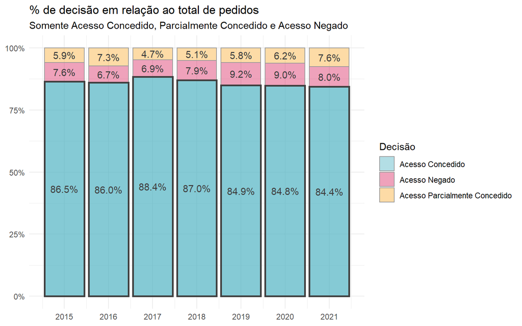

```r
pedidos_cgu %>%
  filter(decisao %in% c(
    "Acesso Concedido",
    "Acesso Parcialmente Concedido",
    "Acesso Negado"
  )) %>%
  mutate(data_resposta = floor_date(data_resposta, unit = "year")) %>%
  group_by(data_resposta = year(data_resposta), decisao) %>%
  summarise(qt = n() / 1e3, .groups = "drop") %>%
  mutate(decisao = fct_reorder(str_wrap(decisao, 40), qt)) %>%
  group_by(data_resposta) %>%
  mutate(qt_ano = sum(qt)) %>%
  ungroup() %>%
  ggplot(aes(x = data_resposta, y = qt / qt_ano, fill = decisao)) +
  geom_col(position = "fill", color = "gray60", alpha = .4) +
  geom_col(data = . %>%  filter(decisao == "Acesso Concedido"),
           color = "gray25",
           alpha = .4,
           size = 1,
           show.legend = F) +
  geom_text(aes(label = scales::percent(qt / qt_ano, accuracy = 0.1)),
            position = position_stack(vjust = .5),
            color = "gray25") +
  scale_y_continuous(labels = scales::percent) +
  scale_x_continuous(breaks = 2015:2021, labels = 2015:2021) +
  labs(x = NULL, y = NULL, fill = "Decisão",
       title = "% de decisão em relação ao total de pedidos",
       subtitle = "Somente Acesso Concedido, Parcialmente Concedido e Acesso Negado") +
  theme_minimal() +
  scale_fill_manual(values = cores_decisao[c(1, 3, 4)])
```

## Recursos

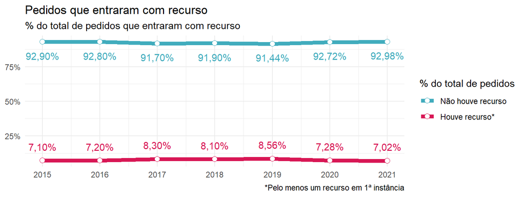

```r
recursos_por_instancia_decisao_e_id <- recursos_cgu %>%
  filter(instancia != "Pedido de Revisão") %>%
  group_by(id_pedido) %>%
  arrange(id_pedido, instancia) %>%
  mutate(ord = 1:n()) %>%
  select(id_pedido, instancia, data_registro_recurso = data_registro, ord) %>%
  filter(ord == max(ord)) %>%
  left_join(select(pedidos_cgu, id_pedido, data_registro_pedido = data_registro, decisao), .) %>%
  mutate(
    instancia = fct_expand(instancia, "Não houve recurso"),
    instancia = replace_na(instancia, "Não houve recurso")
  )

recursos_por_instancia_decisao_e_ano <- recursos_por_instancia_decisao_e_id %>%
  group_by(
    ano = year(data_registro_pedido),
    instancia,
    decisao
  ) %>%
  summarise(n_ano_instancia_decisao = n(), .groups = "drop") %>%
  group_by(ano, instancia) %>%
  mutate(n_ano_instancia = sum(n_ano_instancia_decisao)) %>%
  ungroup() %>%
  group_by(ano, decisao) %>%
  mutate(n_ano_decisao = sum(n_ano_instancia_decisao)) %>%
  ungroup() %>%
  group_by(ano) %>%
  mutate(n_ano = sum(n_ano_instancia_decisao)) %>%
  ungroup()

my_lbl <- function(x) scales::percent(x, accuracy = 0.01, decimal.mark = ",")

recursos_por_instancia_decisao_e_ano %>%
  group_by(
    ano,
    houve_recurso = if_else(instancia == "Não houve recurso", F, T)
  ) %>%
  summarise(n_ano_houve_recurso = sum(n_ano_instancia_decisao), .groups = "drop") %>%
  group_by(ano) %>%
  mutate(per = n_ano_houve_recurso / sum(n_ano_houve_recurso)) %>%
  ungroup() %>%
  ggplot(aes(x = ano, y = per, fill = houve_recurso, color = houve_recurso)) +
  geom_text(data = . %>% filter(houve_recurso), show.legend = F,
            aes(label = my_lbl(per)), nudge_y = .1, check_overlap = T) +
  geom_text(data = . %>% filter(!houve_recurso), show.legend = F,
            aes(label = my_lbl(per)), nudge_y = -.1, check_overlap = T) +
  geom_line(size = 2) +
  geom_point(size = 2.5, shape = 21, fill = "white") +
  scale_color_manual(values = c(tb_colors[["azul"]], aep_colors[["rosa"]]),
                    labels = c("Não houve recurso", "Houve recurso*"),
                    name = "% do total de pedidos") +
  scale_x_continuous(breaks = 2015:2021) +
  scale_y_continuous(labels = scales::percent) +
  theme_minimal() +
  labs(
    title = "Pedidos que entraram com recurso",
    subtitle = "% do total de pedidos que entraram com recurso",
    x = NULL, y = NULL, caption = "*Pelo menos um recurso em 1ª instância")
```

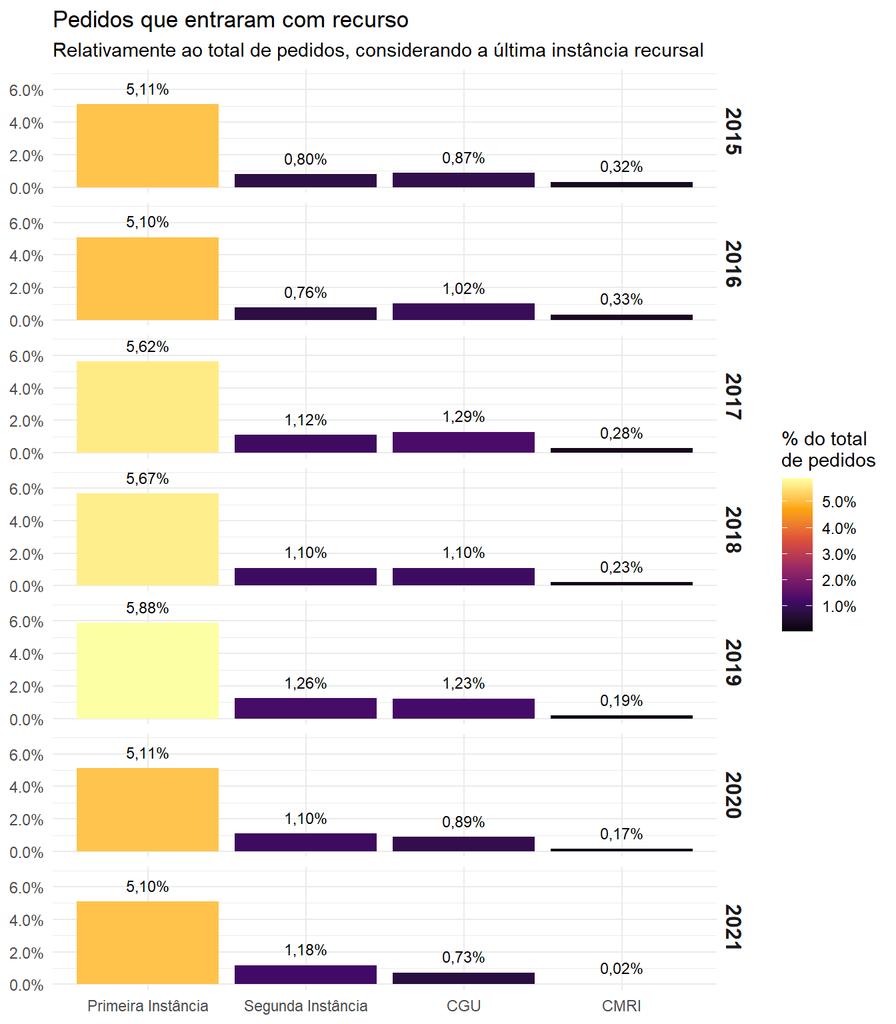

```r
recursos_por_instancia_decisao_e_ano %>%
  select(ano, instancia, n_ano_instancia, n_ano) %>%
  distinct() %>%
  mutate(per = n_ano_instancia / n_ano) %>%
  filter(instancia != "Não houve recurso") %>%
  ggplot(aes(x = fct_reorder(instancia, -per), y = per, fill = per)) +
  geom_col(position = "dodge") +
  geom_text(aes(label = my_lbl(per)), size = 3,
            nudge_y = .01, show.legend = F) +
  scale_y_continuous(labels = scales::percent) +
  scale_fill_continuous(labels = scales::percent, type = "viridis", option = "B") +
  facet_grid(ano ~ .) +
  theme_minimal() +
  theme(strip.text.y = element_text(face = "bold", size = 12)) +
  labs(
    title = "Pedidos que entraram com recurso",
    subtitle = "Relativamente ao total de pedidos, considerando a última instância recursal",
    x = NULL, y = NULL, fill = "% do total\nde pedidos"
  )
```

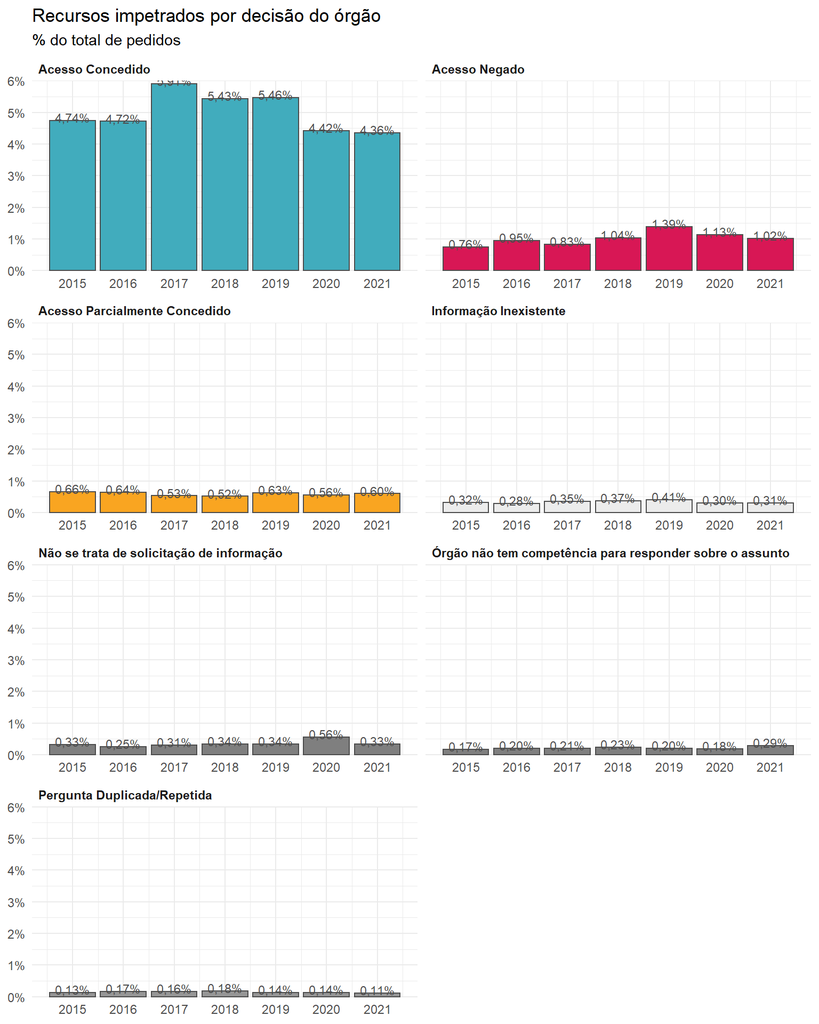

```r
recursos_por_instancia_decisao_e_ano %>%
  #filter(instancia != "Não houve recurso") %>%
  # mutate(houve_recurso = if_else(instancia == "Não houve recurso", F, T)) %>%
  group_by(
    ano,
    decisao,
    houve_recurso = if_else(instancia == "Não houve recurso", F, T)
  ) %>%
  summarise(per = sum(n_ano_instancia_decisao) / n_ano, .groups = "drop") %>%
  ungroup() %>%
  distinct() %>%
  filter(houve_recurso) %>%
  ggplot(aes(fill = fct_rev(decisao), y = per, x = ano)) +
  geom_col(show.legend = F, color = "gray30") +
  geom_text(show.legend = F, aes(label = my_lbl(per)), color = "gray30", size = 3, nudge_y = .001) +
  facet_wrap(. ~ decisao, ncol = 2, scales = "free_x") +
  scale_y_continuous(labels = ~ scales::percent(., accuracy = 1), expand = c(0, 0)) +
  theme_minimal() +
  theme(strip.text.x = element_text(face = "bold", hjust = 0)) +
  scale_x_continuous(breaks = 2015:2021) +
  labs(
    title = "Recursos impetrados por decisão do órgão",
    subtitle = "% do total de pedidos",
    x = NULL, y = NULL) +
  scale_fill_manual(values = cores_decisao)
```

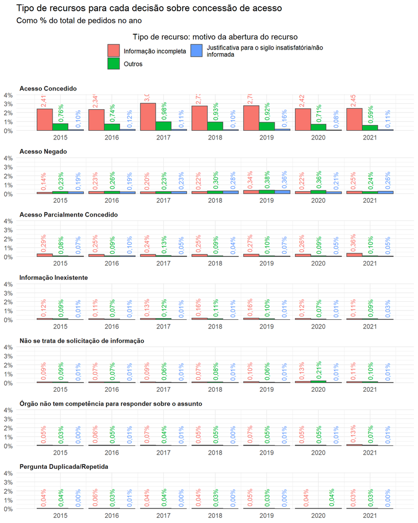

```r
recursos_por_instancia_decisao_e_id %>%
  left_join(select(recursos_cgu, id_pedido, instancia, tipo_recurso)) %>%
  na.omit %>%
  group_by(
    ano = year(data_registro_pedido),
    tipo_recurso,
    decisao
  ) %>%
  summarise(n_tipo_recurso_decisao = n(), .groups = "drop") %>%
  inner_join(distinct(select(recursos_por_instancia_decisao_e_ano, ano, decisao, n_ano))) %>%
  mutate(per = n_tipo_recurso_decisao / n_ano) %>%
  filter(tipo_recurso %in% c(
    "Informação incompleta",
    "Informação recebida nãp cprresponde à solicitada",
    "Outros",
    "Justificativa para o sigilo insatisfatória/não informada"
  )) %>%
  mutate(tipo_recurso = str_wrap(tipo_recurso, 50)) %>%
  ggplot(aes(x = ano, y = per, fill = fct_reorder(tipo_recurso, -per))) +
  geom_col(position = "dodge", color = "gray30") +
  facet_wrap(decisao ~ ., ncol = 1, scales = "free_x") +
  geom_text(aes(label = my_lbl(per), color = fct_reorder(tipo_recurso, -per)),
            show.legend = F,
            position = position_dodge(width = 1),
            size = 3,
            angle = 90,
            check_overlap = T,
            vjust = .5,
            hjust = -.1) +
  scale_y_percent(limits = c(0, 0.04)) +
  scale_x_continuous(breaks = 2015:2021) +
  theme_minimal() +
  labs(x = NULL, y = NULL,
       fill = "Tipo de recurso: motivo da abertura do recurso",
       title = "Tipo de recursos para cada decisão sobre concessão de acesso",
       subtitle = "Como % do total de pedidos no ano"
       ) +
  guides(fill = guide_legend(ncol = 2, title.position = "top", title.hjust = .5)) +
  theme(strip.text.x = element_text(hjust = 0, face = "bold"),
        legend.position = "top")
```